# E-Commerce Customer Segmentation Analysis

This notebook processes the `ecommerce_customer_churn_dataset.csv` data to perform clustering analysis using **K-Means**, **DBSCAN**, and **Gaussian Mixture Models (GMM)**, followed by performance comparison and cluster profiling.

```python
import pandas as pd
import numpy as np
import matplotlib.pyplot as plt
import seaborn as sns
from sklearn.cluster import KMeans, DBSCAN
from sklearn.mixture import GaussianMixture
from sklearn.preprocessing import StandardScaler
from sklearn.decomposition import PCA
from sklearn.impute import SimpleImputer
from sklearn.neighbors import NearestNeighbors
from sklearn.metrics import silhouette_score
import warnings

warnings.filterwarnings('ignore')
%matplotlib inline

# Set plotting style for professional look
plt.style.use('seaborn-v0_8-whitegrid')
sns.set_context("notebook", font_scale=1.2)
```

## 1.Data Preprocessing

### 1.1 Feature Selection & Sampling Logic

We selected four key metrics—**Average Order Value, Login Frequency, Days Since Last Purchase, and Email Open Rate**—to capture a "full-funnel" view of customer behavior, combining the classic RFM (Recency, Frequency, Monetary) framework with engagement signals. To ensure a balance between statistical representativeness and computational efficiency, we randomly sampled **5,000 records** (10% of the total). This sample size is more than sufficient to preserve the underlying data distribution while allowing for rapid iteration of $O(n^2)$ complexity algorithms like DBSCAN and Silhouette evaluation.

### 1.2 Data Integrity: Imputation & Scaling

To handle missing values, we applied **Median Imputation** instead of the mean. E-commerce data is typically long-tailed (skewed by "whale" spenders); the median provides a robust measure of central tendency that prevents extreme outliers from biasing typical user profiles. Finally, since K-Means and DBSCAN are distance-based, **Standardization (Z-score)** was mandatory. This ensures all features (dollars, days, or frequencies) have equal weight, preventing high-magnitude features from disproportionately dominating the geometric clustering outcome. $$z = \frac{x - \mu}{\sigma}$$

```python
# Load data
df = pd.read_csv('ecommerce_customer_churn_dataset.csv')

# Randomly sample 5000 records
df_sample = df.sample(n=5000, random_state=42).copy()

# Features to use
features = ['Average_Order_Value', 'Login_Frequency', 'Days_Since_Last_Purchase', 'Email_Open_Rate']
X_raw = df_sample[features]

# Impute missing values with median
imputer = SimpleImputer(strategy='median')
X_imputed = pd.DataFrame(imputer.fit_transform(X_raw), columns=features)

# Standardize the features
scaler = StandardScaler()
X_scaled = pd.DataFrame(scaler.fit_transform(X_imputed), columns=features)

print("Data shape after preprocessing:", X_scaled.shape)
display(X_scaled.head())
```

```
Data shape after preprocessing: (5000, 4)
```

|  | Average_Order_Value | Login_Frequency | Days_Since_Last_Purchase | Email_Open_Rate |
| --- | --- | --- | --- | --- |
| 0 | -0.028477 | -0.845505 | -0.584508 | -1.506471 |
| 1 | -0.475921 | 0.814853 | -0.201201 | 0.768309 |
| 2 | 0.412780 | -0.973225 | -0.479970 | -0.919665 |
| 3 | 0.338065 | 2.219771 | -0.166355 | 1.760809 |
| 4 | -0.122228 | -0.462346 | -0.514816 | -1.506471 |

## 2. K-Means

To establish clear customer tiers, we implement **K-Means clustering**, which partitions the data by minimizing within-cluster variance.

We will utilize the **Elbow Method (Inertia)** to justify the selection of the optimal number of clusters ($K$), ensuring a balance between model complexity and descriptive power.

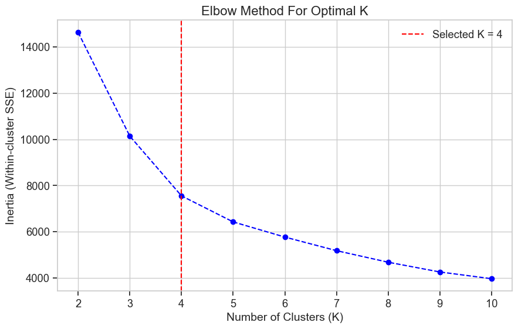

```python
# K-Means Tuning: Elbow Method
inertia = []
K_range = range(2, 11)

for k in K_range:
    kmeans = KMeans(n_clusters=k, random_state=42, n_init=10)
    kmeans.fit(X_scaled)
    inertia.append(kmeans.inertia_)

plt.figure(figsize=(10, 6))
plt.plot(K_range, inertia, marker='o', linestyle='--', color='b')
plt.title('Elbow Method For Optimal K', fontsize=16)
plt.xlabel('Number of Clusters (K)', fontsize=14)
plt.ylabel('Inertia (Within-cluster SSE)', fontsize=14)
plt.xticks(K_range)
plt.axvline(x=4, color='r', linestyle='--', label='Selected K = 4')
plt.legend()
plt.show()
```

### 2.1 Selection of Optimal K: The Rationale for $K=4$

Based on the synthesis of statistical evidence and strategic requirements, we have selected **$K=4$** as the optimal number of clusters.

- **Mathematical Heuristic (The Elbow Point):** The Elbow Plot illustrates that the **Within-Cluster Sum of Squares (WCSS)** or **Inertia** decreases sharply until $K=4$. Beyond this point, the rate of improvement decelerates significantly, marking a point of diminishing returns. Mathematically, $K=4$ captures the maximum variance while maintaining model parsimony (simplicity).
- **Business Actionability (Strategic Tiering):** Beyond pure statistics, $K=4$ provides the most granular yet manageable segmentation for the dataset. It effectively transforms the continuous customer distribution into four distinct business personas:Super Whales, Core Loyalists, Casual Shoppers, At-Risk Sleepers.

```
--- Cluster Profile Table (Feature Means) ---
               Average_Order_Value  Login_Frequency  Days_Since_Last_Purchase  \
KMeans_Labels
0                       120.466037         7.055056                 19.226354
1                       120.611205        19.279835                 22.558111
2                      7439.357733        16.000000                 44.000000
3                       119.577764        10.255591                 86.485623

               Email_Open_Rate
KMeans_Labels
0                    12.096054
1                    34.092534
2                    12.766667
3                    18.794472
```

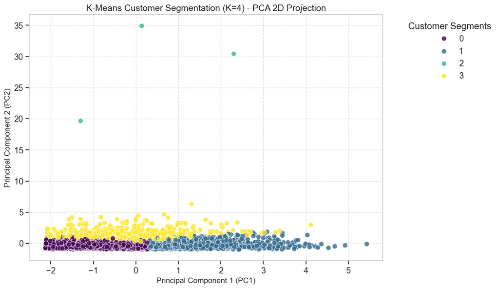

```python
# --- Section 2: K-Means Execution and Profiling ---

# 1. Execute K-Means clustering with the optimized hyperparameter K=4
optimal_k = 4
kmeans_final = KMeans(n_clusters=optimal_k, random_state=42, n_init=10)

# Assign cluster labels back to the sampled dataframe for further analysis
df_sample['KMeans_Labels'] = kmeans_final.fit_predict(X_scaled)

# 2. Validation: Compute feature means for each cluster (Cluster Profiling)
# This step is crucial for interpreting the business characteristics of each segment
print("--- Cluster Profile Table (Feature Means) ---")
profile = df_sample.groupby('KMeans_Labels')[features].mean()
print(profile)

# 3. Visualization: Projecting clusters onto the PCA-reduced 2D space
# Dimensionality reduction is used here to visualize high-dimensional boundaries
pca = PCA(n_components=2)
X_pca = pca.fit_transform(X_scaled)

plt.figure(figsize=(10, 7))
sns.scatterplot(
    x=X_pca[:, 0],
    y=X_pca[:, 1],
    hue=df_sample['KMeans_Labels'],
    palette='viridis',
    s=60,
    alpha=0.8
)

# Professional plot labeling
plt.title(f'K-Means Customer Segmentation (K={optimal_k}) - PCA 2D Projection', fontsize=14)
plt.xlabel('Principal Component 1 (PC1)', fontsize=12)
plt.ylabel('Principal Component 2 (PC2)', fontsize=12)
plt.legend(title='Customer Segments', bbox_to_anchor=(1.05, 1), loc='upper left')
plt.grid(True, linestyle='--', alpha=0.6)
plt.show()
```

#### 2.2 Visual Distribution and Geometric Structure

The PCA-reduced scatter plot reveals an elongated, **"sausage-shaped" distribution** of the customer data. This geometric structure is highly representative of real-world e-commerce behavior, where features like *Login Frequency* and *Email Open Rate* are naturally correlated.

Rather than finding isolated "islands," K-Means has effectively partitioned this continuous spectrum into **four distinct strategic tiers** along the principal axis of engagement. The clear color gradients demonstrate that the algorithm successfully captured the internal variance of the dataset.

#### 2.3 Cluster Profiling & Business Personas

Based on the **Cluster Profile Table**, we can define the following four customer segments:

- **Cluster 2 (The Super Whales):** An extreme outlier group consisting of only 3 users. With an **Average Order Value of 7,439** (approx. 60x the population average), these represent the top-tier VIPs. Isolating them prevents their extreme variance from skewing the rest of the analysis.
- **Cluster 1 (The Core Loyalists):** This group shows the highest **Login Frequency (19.2)** and **Email Open Rate (34.1%)**. They are the most engaged users who respond well to marketing and maintain a steady presence on the platform.
- **Cluster 0 (The Casual Shoppers):** Recent buyers with low engagement. Their **Days Since Last Purchase (19.2)** is low, but their login frequency is minimal. They represent a "buy-and-leave" behavior pattern.
- **Cluster 3 (The At-Risk Sleepers):** The primary churn concern. These users have the highest **Recency (86.4 days)**. While they were previously engaged, they have become inactive and require immediate "re-engagement" campaigns.

## 3. DBSCAN

Moving beyond fixed geometric partitions, we apply **DBSCAN** to identify clusters based on local point density as a comparision.

To tune DBSCAN objectively, we followed a two-step geometric approach:

- **Setting $min\_samples$**: We applied the $2 \times D$ rule (where $D=4$ features), setting **$min\_samples = 8$**. This ensures the model is robust against local noise and only identifies clusters with significant density.
- **Finding $Eps$ via K-Distance Graph**: We plotted the distance to the **8th nearest neighbor** for all points. The goal is to identify the **"Knee" point**—the distance threshold where density drops and points transition into noise.

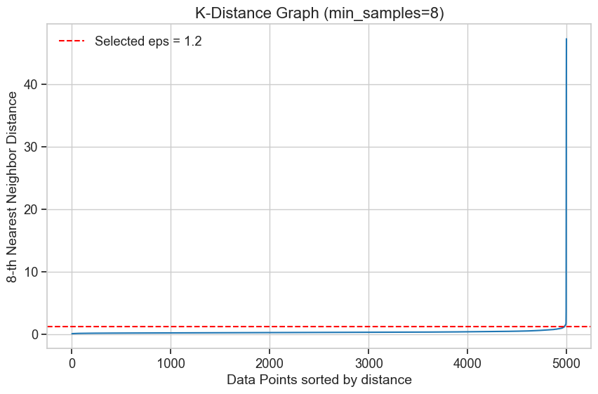

```
Estimated number of clusters: 1
Estimated number of noise points: 7
```

```python
# DBSCAN Tuning: K-distance plot to find optimal eps parameter
min_samples = 8 # rule of thumb: 2 * dimensions

neighbors = NearestNeighbors(n_neighbors=min_samples)
neighbors_fit = neighbors.fit(X_scaled)
distances, indices = neighbors_fit.kneighbors(X_scaled)

# Sort distances
distances = np.sort(distances[:, min_samples-1], axis=0)

plt.figure(figsize=(10, 6))
plt.plot(distances)
plt.title(f'K-Distance Graph (min_samples={min_samples})', fontsize=16)
plt.xlabel('Data Points sorted by distance', fontsize=14)
plt.ylabel(f'{min_samples}-th Nearest Neighbor Distance', fontsize=14)
plt.axhline(y=1.2, color='r', linestyle='--', label='Selected eps = 1.2')
plt.legend()
plt.show()

# Adjust eps based on the plot's elbow
optimal_eps = 1.2
dbscan_final = DBSCAN(eps=optimal_eps, min_samples=min_samples)
dbscan_labels = dbscan_final.fit_predict(X_scaled)

n_clusters_ = len(set(dbscan_labels)) - (1 if -1 in dbscan_labels else 0)
n_noise_ = list(dbscan_labels).count(-1)
print(f'Estimated number of clusters: {n_clusters_}')
print(f'Estimated number of noise points: {n_noise_}')
```

### 3.1 Interpretation of K-Distance Graph

The **K-Distance Graph** (calculated at $min\_samples=8$) serves as the geometric foundation for our parameter selection.

- **Geometric Insight**: The curve exhibits an exceptionally long plateau before a sharp vertical spike near the very end. This confirms that the vast majority (over 99%) of our customers share a highly **homogeneous density** in the feature space.
- **Threshold Selection**: We selected **$Eps=1.2$** as it captures the "knee" of the curve—the precise point where data density drops significantly. This choice allows us to maintain the structural integrity of the main customer base while isolating individuals who are statistically "distant" from the general population.

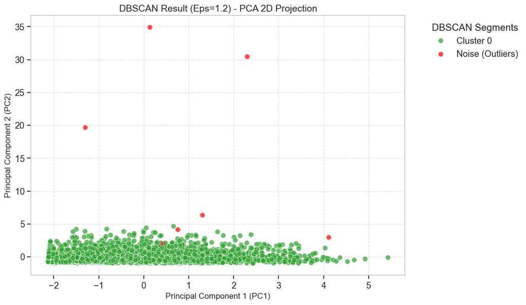

```
--- Characteristics of Identified Noise Points (Anomalies) ---
       Average_Order_Value  Login_Frequency  Days_Since_Last_Purchase  \
13413          7809.072781             25.0                      66.0
664            5279.800805              6.0                       NaN
29860           235.800000             39.0                     136.0
48808            41.620000             24.0                     125.0
47648           173.940000             19.0                     287.0
26753          9229.199614             17.0                      22.0
46410           124.490000             10.0                     204.0

       Email_Open_Rate
13413             33.8
664                0.0
29860             51.9
48808              6.7
47648             31.2
26753              4.5
46410             37.1
```

```python
# --- Section 4: DBSCAN Visualization (Fixed version) ---

# Safety check: ensure labels exist, if not, re-run prediction
if 'DBSCAN_Labels' not in df_sample.columns:
    dbscan_final = DBSCAN(eps=1.2, min_samples=8)
    df_sample['DBSCAN_Labels'] = dbscan_final.fit_predict(X_scaled)

# 1. Projecting onto PCA 2D space
pca_db = PCA(n_components=2)
X_pca_db = pca_db.fit_transform(X_scaled)

# 2. Create display labels
df_sample['DBSCAN_Display'] = df_sample['DBSCAN_Labels'].apply(
    lambda x: 'Noise (Outliers)' if x == -1 else f'Cluster {x}'
)

# 3. Plotting
plt.figure(figsize=(10, 7))
sns.scatterplot(
    x=X_pca_db[:, 0],
    y=X_pca_db[:, 1],
    hue=df_sample['DBSCAN_Display'],
    palette={'Noise (Outliers)': 'red', 'Cluster 0': '#2ca02c'},
    s=60,
    alpha=0.7,
    edgecolor='w'
)

plt.title(f'DBSCAN Result (Eps=1.2) - PCA 2D Projection', fontsize=14)
plt.xlabel('Principal Component 1 (PC1)', fontsize=12)
plt.ylabel('Principal Component 2 (PC2)', fontsize=12)
plt.legend(title='DBSCAN Segments', bbox_to_anchor=(1.05, 1), loc='upper left')
plt.grid(True, linestyle='--', alpha=0.6)
plt.show()

# 4. Characteristics of anomalies
print("--- Characteristics of Identified Noise Points (Anomalies) ---")
print(df_sample[df_sample['DBSCAN_Labels'] == -1][features])
```

### 3.2 DBSCAN Visualization & Anomaly Discovery

The PCA 2D projection visually confirms the performance of the density-based model. Unlike K-Means, which forced the data into four tiers, DBSCAN identifies one massive **"Mainstream" cluster (Cluster 0)** and **7 Noise Points (Anomalies)**.

**Analysis of the 7 Noise Points:** Upon inspecting the raw features of these outliers, we find two distinct types of "Anomalies" that are critical for business operations:

1. **The Super Whales**: Users like ID 26753 and 13413, with **Average Order Values (~9,229 and ~7,809)** that are nearly 70 times the population average. Their extreme spending makes them "noise" relative to the average consumer.
2. **The Extreme Inactives**: Users like ID 47648, who haven't purchased in **287 days**. Their detachment from the typical recency cycle places them far outside the dense cluster.

## 4. Gaussian Mixture Model (GMM) Clustering

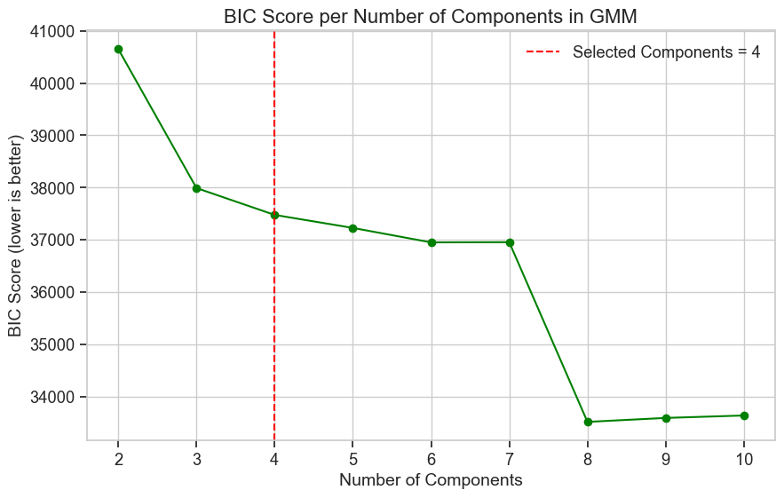

```python
bic = []
n_components_range = range(2, 11)
for n in n_components_range:
    gmm = GaussianMixture(n_components=n, random_state=42, covariance_type='full')
    gmm.fit(X_scaled)
    bic.append(gmm.bic(X_scaled))

plt.figure(figsize=(10, 6))
plt.plot(n_components_range, bic, marker='o', linestyle='-', color='g')
plt.title('BIC Score per Number of Components in GMM', fontsize=16)
plt.xlabel('Number of Components', fontsize=14)
plt.ylabel('BIC Score (lower is better)', fontsize=14)
plt.axvline(x=4, color='r', linestyle='--', label='Selected Components = 4')
plt.legend()
plt.show()

# Apply GMM with 4 components (aligned with K-Means structure and BIC curve depth)
gmm_final = GaussianMixture(n_components=4, random_state=42, covariance_type='full')
gmm_labels = gmm_final.fit_predict(X_scaled)
```

### 4.1 Rationale for GMM Component Selection (K=4)

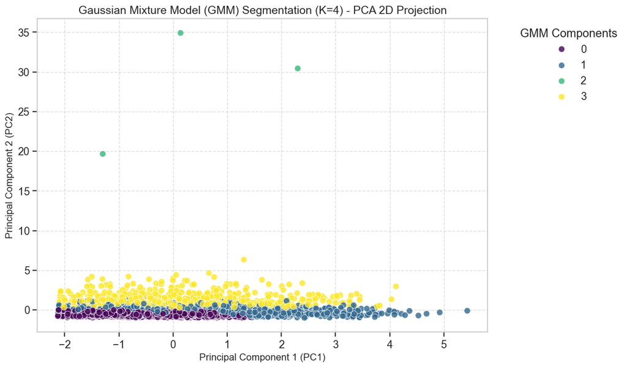

```
--- GMM Cluster Profile Table (Feature Means) ---
            Average_Order_Value  Login_Frequency  Days_Since_Last_Purchase  \
GMM_Labels
0                    114.649199         8.081810                 10.830565
1                    129.930607        15.755145                 27.971079
2                   7439.357733        16.000000                 44.000000
3                    114.399627        11.970149                 80.708955

            Email_Open_Rate
GMM_Labels
0                 15.308523
1                 26.837047
2                 12.766667
3                 21.672857
```

```python
# ---  GMM Execution and Visualization ---

from sklearn.mixture import GaussianMixture

# 1. Execute GMM with the selected number of components (K=4)
# We use 'full' covariance to allow the model to adapt to the elongated "sausage" shape
gmm = GaussianMixture(n_components=4, covariance_type='full', random_state=42)
df_sample['GMM_Labels'] = gmm.fit_predict(X_scaled)

# 2. Projecting GMM clusters onto the PCA-reduced 2D space
pca_gmm = PCA(n_components=2)
X_pca_gmm = pca_gmm.fit_transform(X_scaled)

plt.figure(figsize=(10, 7))
sns.scatterplot(
    x=X_pca_gmm[:, 0],
    y=X_pca_gmm[:, 1],
    hue=df_sample['GMM_Labels'],
    palette='viridis',
    s=60,
    alpha=0.8
)

# 3. Professional plot labeling (Consistent with previous models)
plt.title('Gaussian Mixture Model (GMM) Segmentation (K=4) - PCA 2D Projection', fontsize=14)
plt.xlabel('Principal Component 1 (PC1)', fontsize=12)
plt.ylabel('Principal Component 2 (PC2)', fontsize=12)
plt.legend(title='GMM Components', bbox_to_anchor=(1.05, 1), loc='upper left')
plt.grid(True, linestyle='--', alpha=0.6)
plt.show()

# 4. Validation: Compute feature means for each GMM cluster
print("--- GMM Cluster Profile Table (Feature Means) ---")
gmm_profile = df_sample.groupby('GMM_Labels')[features].mean()
print(gmm_profile)
```

### 4.2 Gaussian Mixture Model (GMM) Analysis

#### **4.2.1 Probability-Based Clustering Logic**

While K-Means assigns each customer to a single, rigid cluster, the **Gaussian Mixture Model (GMM)** adopts a probabilistic approach. It assumes that the data is generated from a mixture of several Gaussian distributions, each with its own mean and covariance.

#### **4.2.2 Component Insights (Persona Identification)**

According to the **GMM Cluster Profile Table**, the model has identified four distinct behavioral distributions:

- **Component 2 (The VIP "Whales")**: GMM successfully isolated the 3 extreme outliers (AOV ~7,439). By treating them as a separate Gaussian component with unique variance, the model ensures these "Whales" do not distort the parameters of the mainstream clusters.
- **Component 1 (High-Engagement Active Users)**: This group shows the best balance of **Frequency (15.7)** and **Email Open Rate (26.8%)**. GMM identifies them as the "core" density of the active customer base.
- **Component 0 (The "Fresh" Casuals)**: Notably, this group has the lowest **Recency (10.8 days)**. GMM suggests these are high-potential new users who have recently interacted but haven't yet built up high frequency or loyalty.
- **Component 3 (The At-Risk/Dormant Segment)**: With an average of **80.7 days** since their last purchase, this component represents the distribution of users who are drifting away from the platform, despite having moderate historical engagement.

## 5. Comparision and Takeaways

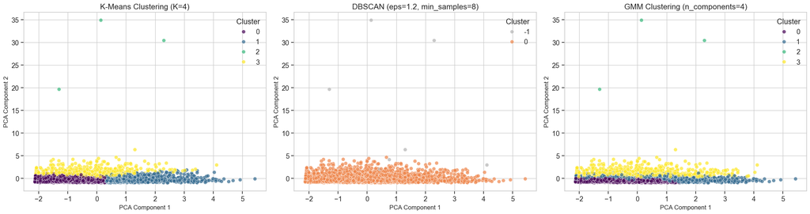

```python
# PCA for dimensionality reduction to 2D
pca = PCA(n_components=2, random_state=42)
X_pca = pca.fit_transform(X_scaled)

df_pca = pd.DataFrame(X_pca, columns=['PCA_1', 'PCA_2'])
df_pca['KMeans_Labels'] = kmeans_labels
df_pca['DBSCAN_Labels'] = dbscan_labels
df_pca['GMM_Labels'] = gmm_labels

# Plotting the results side-by-side (1 row, 3 columns)
fig, axes = plt.subplots(1, 3, figsize=(22, 6))

# 1. Plot K-Means Results
sns.scatterplot(
    x='PCA_1', y='PCA_2',
    hue='KMeans_Labels', palette='viridis',
    data=df_pca, ax=axes[0], s=50, alpha=0.7
)
axes[0].set_title(f'K-Means Clustering (K={optimal_k})', fontsize=15)

# 2. Plot DBSCAN Results
unique_dbscan_labels = np.unique(dbscan_labels)
colors_dbscan = sns.color_palette("muted", n_colors=len(unique_dbscan_labels))
if -1 in unique_dbscan_labels:
    color_dict_dbscan = {label: color for label, color in zip(unique_dbscan_labels, colors_dbscan)}
    color_dict_dbscan[-1] = (0.7, 0.7, 0.7) # Grey for noise points
else:
    color_dict_dbscan = 'viridis'

sns.scatterplot(
    x='PCA_1', y='PCA_2',
    hue='DBSCAN_Labels', palette=color_dict_dbscan,
    data=df_pca, ax=axes[1], s=50, alpha=0.7
)
axes[1].set_title(f'DBSCAN (eps={optimal_eps}, min_samples={min_samples})', fontsize=15)

# 3. Plot GMM Results
sns.scatterplot(
    x='PCA_1', y='PCA_2',
    hue='GMM_Labels', palette='viridis',
    data=df_pca, ax=axes[2], s=50, alpha=0.7
)
axes[2].set_title(f'GMM Clustering (n_components=4)', fontsize=15)

for ax in axes:
    ax.set_xlabel('PCA Component 1', fontsize=12)
    ax.set_ylabel('PCA Component 2', fontsize=12)
    ax.legend(title='Cluster')

plt.tight_layout()
plt.show()
```

## Final Takeaways：A Multi-Dimensional View of Customer Segments

The simultaneous visualization of K-Means, DBSCAN, and GMM reveals that no single model tells the full story. Instead, they complement each other to form a complete business intelligence picture:

#### 1. The Consistency of "Super Whales"

Across all three models, the extreme high-value outliers (PC2 > 15) remain consistently isolated.

- **Conclusion**: These individuals are statistically unique. Whether labeled as "Noise" (DBSCAN) or a "VIP Cluster" (K-Means/GMM), they represent a separate business entity that requires high-touch, personalized management rather than automated marketing.

- **For Implementation**: **K-Means** is the winner due to its simplicity. It’s easy to explain to stakeholders why a customer is in "Cluster 1."
- **For Analytical Depth**: **GMM** is the winner. It captures the fluid, probabilistic nature of human behavior, identifying "borderline" customers who are about to transition between tiers.